# Apresentação da proposta

Luiz Fernando Maia

```r
library(dplyr)
library(ggplot2)
library(tidytext)
library(rtweet)

load("data/transcripts.RData")
load("data/ratings.RData")
```

## Proposta inicial

Inicialmente, minha ideia era utilizar dados do twitter (texto e hora do tweet) de alguma partida de futebol e comparar a frequência de determinadas palavras com os eventos do jogo.

No entanto, um problema que surgiu foi que a api gratuita do tweet aparentemente não retorna tweets de maneira constante ao decorrer da partida. Segue um exemplo em que temos tweets apenas para alguns intervalos de tempo do jogo.

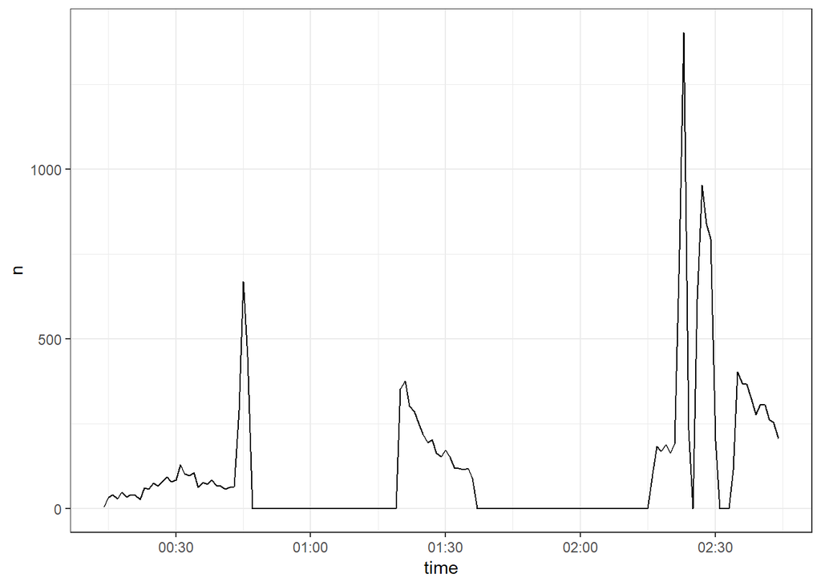

```r
tweets = parse_stream("CEAxFLU.json")
ts_plot(tweets, by = "mins") + # função do rtweet que utiliza o ggplot
  theme_bw()
```

Este problema me fez desistir da proposta inicial e buscar outras opções para o trabalho final.

## Nova proposta

Alguns meses atrás, navegando no Reddit, encontrei uma visualização que me chamou bastante atenção:

[figure not shown]

[Link da visualização](https://www.reddit.com/r/dataisbeautiful/comments/8a4gbr/the_office_characters_most_distinguishing_words_oc/?sort=confidence)

na época, eu estava estudando mineração de textos e tive a ideia de utilizar métodos de text mining para buscar palavras que identifiquem cada personagem e avaliar a relação entre a quantidade de falas de um personagem em um episódio com a nota do episódio no IMDB. Como eu nunca assisti The Office, a série desta visualização, decidi utilizar os dados da série [Avatar: The Last Airbender (ATLA)](https://en.wikipedia.org/wiki/Avatar:_The_Last_Airbender).

## Datasets

Os datasets que serão utilizados são:

- O script dos 61 episódios do ATLA disponível em: http://avatar.wikia.com/wiki/Avatar_Wiki:Transcripts;
- As notas do IMDB desta série que pode ser encontrada em: https://www.imdb.com/title/tt0417299/.

Ambos os conjuntos de dados foram coletados via web scraping. O código do scrape está no arquivo *scrape.R*.

Colunas do data frame dos roteiros

```r
glimpse(transcripts)
```

```
## Observations: 9,992
## Variables: 4
## $ speaker  <chr> "Katara", "Sokka", "Katara", "Sokka", "Katara", "Kata...
## $ text     <chr> "Water. Earth. Fire. Air. My grandmother used to tell...
## $ epi_num  <int> 1, 1, 1, 1, 1, 1, 1, 1, 1, 1, 1, 1, 1, 1, 1, 1, 1, 1,...
## $ epi_name <fct> The Boy in the Iceberg, The Boy in the Iceberg, The B...
```

Notas dos episódios

```r
ratings
```

```
##  [1] 8.1 8.3 8.5 8.2 8.2 8.0 8.2 8.9 8.0 7.9 7.1 9.0 9.1 8.0 7.9 8.5 8.1
## [18] 8.6 9.4 9.7 8.7 8.2 8.5 7.8 7.6 9.1 9.4 8.9 8.5 8.8 8.7 8.4 9.0 8.7
## [35] 9.2 8.8 9.0 8.6 9.0 9.6 8.7 8.4 8.0 8.8 8.5 9.4 8.2 9.1 7.8 9.1 9.4
## [52] 8.9 9.1 8.7 9.2 8.9 8.6 9.1 9.5 9.7 9.8
```

## Principais palavras por personagem

Inicialmente, realizarei um pre-processamento nos textos, removerei as introduções e tudo que estiver entre colchetes.

Exemplo de texto antes da limpeza

```r
transcripts$text[2]
```

```
## [1] "It's not getting away from me this time. [Close-up of the boy as he grins confidently over his shoulder in the direction of the girl.] Watch and learn, Katara. This is how you catch a fish.\n"
```

```r
intro = transcripts$text[1]

transcripts = transcripts %>%
  filter(text != intro) %>% # tirando as introducoes
  mutate(text = stringr::str_replace_all(text, '\\[(.*?)\\]', ''), # tirando o que ta entre colchetes
         text = qdapRegex::rm_number(text))
```

Exemplo de texto depois da limpeza

```r
transcripts$text[1] # índice 1 pois removi a introdução
```

```
## [1] "It's not getting away from me this time. Watch and learn, Katara. This is how you catch a fish."
```

Agora, colocarei o texto no formato de um data frame de uma palavra por linha, com todas as palavras em caixa baixa e removerei as seguintes stop words

```r
sort(unique(stop_words$word))
```

```
##   [1] "a"             "a's"           "able"          "about"
##   [5] "above"         "according"     "accordingly"   "across"
##   [9] "actually"      "after"         "afterwards"    "again"
##  [13] "against"       "ain't"         "all"           "allow"
##  [17] "allows"        "almost"        "alone"         "along"
##  [21] "already"       "also"          "although"      "always"
##  [25] "am"            "among"         "amongst"       "an"
##  [29] "and"           "another"       "any"           "anybody"
##  [33] "anyhow"        "anyone"        "anything"      "anyway"
##  [37] "anyways"       "anywhere"      "apart"         "appear"
##  [41] "appreciate"    "appropriate"   "are"           "area"
##  [45] "areas"         "aren't"        "around"        "as"
##  [49] "aside"         "ask"           "asked"         "asking"
##  [53] "asks"          "associated"    "at"            "available"
##  [57] "away"          "awfully"       "b"             "back"
```

[output cut: 167 more lines]

```r
ut = transcripts %>%
  unnest_tokens(word, text) %>%
  anti_join(stop_words) # retirando stop words
glimpse(ut)
```

```
## Observations: 34,602
## Variables: 4
## $ speaker  <chr> "Sokka", "Sokka", "Sokka", "Sokka", "Sokka", "Sokka",...
## $ epi_num  <int> 1, 1, 1, 1, 1, 1, 1, 1, 1, 1, 1, 1, 1, 1, 1, 1, 1, 1,...
## $ epi_name <fct> The Boy in the Iceberg, The Boy in the Iceberg, The B...
## $ word     <chr> "time", "watch", "learn", "katara", "catch", "fish", ...
```

Contagem de palavras por personagem (após remoção de stop words):

```r
count_speaker = ut %>%
  count(speaker) %>%
  arrange(desc(n))
count_speaker
```

```
## # A tibble: 358 x 2
##    speaker     n
##    <chr>   <int>
##  1 Sokka    5521
##  2 Aang     5027
##  3 Katara   4102
##  4 Zuko     2374
##  5 Iroh     1658
##  6 Toph     1489
##  7 Azula     944
##  8 Zhao      566
##  9 Jet       455
## 10 Hakoda    341
## # ... with 348 more rows
```

Optei por utilizar apenas os 18 personagens com maior número de palavras e calcular as palavras mais utilizadas e a medida tf-idf considerando cada personagem como um documento. A medida tf-idf nos permite avaliar palavras que caracterizam um determinado documento, neste caso personagem, em relação a um conjunto de documentos. Ela é calculada da seguinte forma:

$$w_{t,d} = \frac{tf_{t,d}}{\sum_{t' \in d}f_{t',d}} \times log \Bigg( \frac{N}{n_t} \Bigg)$$

em que

- $w_{t,d}$ é o valor do o peso para o termo $t$ no documento $d$;
- $tf_{t,d}$ é a quantidade de vezes que o termo $t$ aparece no documento $d$;
- $\sum_{t' \in d}f_{t',d}$ é a quantidade total de termos do documento $d$;
- $N$ é o número total de documentos;
- $n_t$ é o número de documentos que contém o termo $t$.

```r
personagens = count_speaker$speaker[1:18]

tfidf = ut %>%
  filter(speaker %in% personagens) %>%
  count(word, speaker) %>%
  bind_tf_idf(word, speaker, n) %>%
  arrange(desc(tf_idf))
```

Visualizando as palavras mais utilizadas e os maiores tf-idf por personagem

```r
tmp1 = tibble(speaker = count_speaker$speaker[1:18],
                   order_speaker = 1:18)

tmp2 = tfidf %>%
  inner_join(tmp1) %>%
  mutate(speaker = reorder(speaker, order_speaker)) %>%
  arrange(speaker, desc(n)) %>%
  group_by(speaker) %>%
  do(head(., 10)) %>%
  ungroup() %>%
  arrange(speaker, n) %>%
  mutate(order_word = row_number())
tmp3 = tfidf %>%
  inner_join(tmp1) %>%
  mutate(speaker = reorder(speaker, order_speaker)) %>%
  arrange(speaker, desc(tf_idf)) %>%
  group_by(speaker) %>%
  do(head(., 10)) %>%
  ungroup() %>%
  arrange(speaker, tf_idf) %>%
  mutate(order_word = row_number())
```

[figure not shown]

```r
ggplot(tmp2, aes(order_word, n, fill = speaker)) +
  geom_bar(stat = "identity", show.legend = FALSE) +
  facet_wrap(~ speaker, scales = "free", ncol = 6) +
  theme_bw() +
  scale_x_continuous(breaks = tmp2$order_word, labels = tmp2$word) +
  scale_y_continuous(breaks = scales::pretty_breaks(2)) +
  coord_flip() +
  labs(title = "Palavras mais utilizadas por personagens",
       x = NULL,
       y = "n")
```

[figure not shown]

```r
ggplot(tmp3, aes(order_word, tf_idf, fill = speaker)) +
  geom_bar(stat = "identity", show.legend = FALSE) +
  facet_wrap(~ speaker, scales = "free", ncol = 6) +
  xlab("words") +
  ylab("tf-idf") +
  theme_bw() +
  scale_x_continuous(breaks = tmp3$order_word, labels = tmp3$word) +
  scale_y_continuous(breaks = scales::pretty_breaks(2)) +
  coord_flip() +
   labs(title = "Palavras com maiores tf-idf por personagem",
       x = NULL,
       y = "tf-idf")
```

## Relação entre a proporção de falas dos personagens e notas do IMDB

Primeiramente, agrupei as informações das notas com a base do roteiro e criei uma variável para indicar a fração da quantidade de falas dos personagens em relação ao total de falas do episódio.

```r
tmp = tibble(epi_num = unique(transcripts$epi_num), rating = ratings)

prop = transcripts %>%
  inner_join(tmp) %>%
  filter(speaker %in% personagens) %>%
  count(epi_num, rating, speaker) %>%
  group_by(epi_num) %>%
  mutate(prop = n/sum(n))
glimpse(prop)
```

```
## Observations: 387
## Variables: 5
## Groups: epi_num [61]
## $ epi_num <int> 1, 1, 1, 1, 1, 2, 2, 2, 2, 2, 3, 3, 3, 3, 3, 3, 4, 4, ...
## $ rating  <dbl> 8.1, 8.1, 8.1, 8.1, 8.1, 8.3, 8.3, 8.3, 8.3, 8.3, 8.5,...
## $ speaker <chr> "Aang", "Iroh", "Katara", "Sokka", "Zuko", "Aang", "Ir...
## $ n       <int> 47, 7, 50, 31, 8, 30, 3, 35, 33, 12, 52, 13, 32, 32, 2...
## $ prop    <dbl> 0.32867133, 0.04895105, 0.34965035, 0.21678322, 0.0559...
```

Posteriormente, criei uma base com as notas dos episódios.

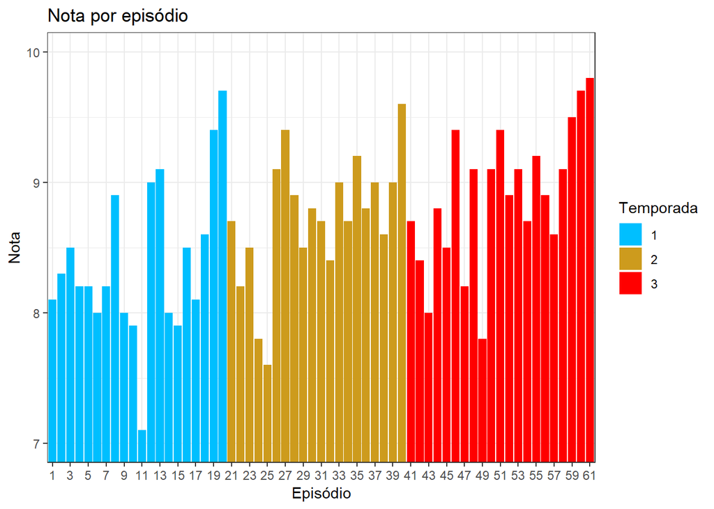

```r
episodios = tibble(Episódio = as.factor(1:61),
                   Nota = ratings,
                   Temporada = as.factor(c(rep(1, 20), rep(2, 20), rep(3, 21))))

episodios %>%
  ggplot(aes(x = Episódio, y = Nota, fill = Temporada)) +
  geom_bar(stat = "identity") +
  scale_fill_manual(values = c("deepskyblue", "goldenrod3", "red")) +
  theme_bw() +
  coord_cartesian(ylim = c(7, 10)) +
  scale_x_discrete(breaks = seq(1, 61, 2)) +
  ggtitle("Nota por episódio")
```

Finalmente, calculei a correlação de Spearman entre a proporção de falas do personagem e a nota do IMDB. Preferi utilizar esta medida de correlação ao invés da correlação de Pearson pois não espero que a correlação entre estas variáveis seja linear.

```r
freq2vec <- function(x) {
  out = NULL
  for(i in 1:61) {
    tmp = prop %>%
      filter(speaker == x,
             epi_num == i) %>%
      .$prop
    out[i] = ifelse(length(tmp) == 0, 0, tmp)
  }
  out
}

mat_freq = ratings %>%
  cbind(sapply(personagens, freq2vec))
colnames(mat_freq)[1] = "rating"

cor_rating = cor(mat_freq, method = "spearman")[-1,1]

sort(cor_rating, decreasing = TRUE)
```

```
##        Zuko        Ozai        Toph       Azula      Hakoda        Suki
##  0.44011830  0.40957611  0.35787257  0.30859284  0.23609850  0.22193422
##        Iroh        Roku        Zhao        Bumi   Long Feng         Mai
##  0.21074101  0.17174359  0.16627787  0.15974255  0.15108082  0.12588468
##        Hama      Pathik         Jet       Sokka        Aang      Katara
##  0.12122290  0.06229572 -0.05067584 -0.38144198 -0.42776043 -0.60494221
```

## Próximos passos

- Construir uma visualização para as correlações;
- Adicionar visualizações intermediárias;
- Como as principais palavras utilizadas por personagens são os nomes de outros personagens, construir um [diagrama de Chord](https://www.r-graph-gallery.com/chord-diagram.html) para visualizar a quantidade de vezes que cada personagem utilizou o nome de outro em suas falas;
- Adicionar comentários/interpretações para as visualizações.